# Projeto INN-1119

Equipe 1: Miguel Angel Ortiz Acuña Kevin Ian Ruiz Vargas José Mauricio Matapi da Silva

14/9/2020

# Base de dados

A base de dados a tratar foi obtida do Sistema de Informações de Nascidos Vivos - SINASC reunidos pela plataforma de Ciência de Dados aplicada à Saude (PCDas). Os dados foram obtidos junto ao DATASUS (Ministério da Saúde), tratados e enriquecidos seguindo uma metodologia própria de ETL da PCDaS, resultando em um dataset anual com todos os registros das declarações de nascidos vivos contidas no SINASC à partir de 1996. A atualização dos dados é realizada pelo DATASUS e a PCDaS extrai os registros anuais assim que disponibilizados. As colunas com nomes em MAIÚSCULO representam dados originais advindos do DATASUS e colunas com nomes iniciando em minúsculo representam dados resultantes de transformação ou enriquecimento.

O alcance do projeto sera analisar a relação dos nascidos vivos em maes menores de idade com respeito a variaveis como raça e escolaridade. Tambem vai ser estudado se a escolaridade é um fator determinante no número de consultas de prenatal e por ultimo saber se o número de consultas de prenatal é um fator no peso, APAGAR1 e APAGAR5 no estado de Pernambuco.

```r
ano2015 <- read.csv("../dados_limpos/gravida_dataset2015.csv")
ano2016 <- read.csv("../dados_limpos/gravida_dataset2016.csv")
ano2017<- read.csv("../dados_limpos/gravida_dataset2017.csv")
```

# Analise do número de nascidos vivos de maes menores de idade em PE entre os anos 2015,2016 e 2017

## Limpeza de dados e pre-processamento

```r
ano2015 %>%
  filter(idademae <= 18) %>%
  select(data_nasc) %>%
  group_by(data_nasc) %>%
  count(data_nasc, sort="F") %>%
  ungroup()  %>%
  mutate(key = c(1:365)) -> prueba

ano2016 %>%
  filter(idademae <= 18) %>%
  select(data_nasc) %>%
  group_by(data_nasc) %>%
  count(data_nasc, sort="F") %>%
  ungroup() %>%
  mutate(key = c(1:366)) -> prueba2

ano2017 %>%
  filter(idademae <= 18) %>%
  select(data_nasc) %>%
  group_by(data_nasc) %>%
  count(data_nasc, sort="F") %>%
  ungroup()  %>%
  mutate(key = c(1:365)) -> prueba3


intervalo <- prueba %>%
  left_join(prueba2, by = "key") %>%
  left_join(prueba3, by = "key") %>%
  select(-c(key)) %>%
  rename(pregnat_per_day_2015 = n.x,
         pregnat_per_day_2016 = n.y,
         pregnat_per_day_2017 = n)
```

### Teste de aderencia KS

Vai ser aplicado o teste de aderencia de Kolmogorov-Smirnov nas 3 variaveis a modelar:

```r
kolmogorov <- sapply(intervalo[,c(2,4,6)], function(y) {
  ks <- ks.test(y, "pnorm", mean(y), sd(y))
  c(statistic=ks$statistic, p.value=ks$p.value)
  setNames(c(ks$statistic, ks$p.value), c("Statistic", "P.value"))
})

kolmogorov
```

```
##           pregnat_per_day_2015 pregnat_per_day_2016 pregnat_per_day_2017
## Statistic           0.05946797            0.0382871           0.06117987
## P.value             0.15124004            0.6584005           0.13009363
```

O resultado obtido demostra normalidade no número de nascidos vivos em menores de idade nos anos 2015, 2016 e 2017.

### Test t-student

```r
t.test(intervalo$pregnat_per_day_2016, intervalo$pregnat_per_day_2015, alternative = "two.sided", conf.level = 0.95,
       var.equal = F)
```

```
##
##  Welch Two Sample t-test
##
## data:  intervalo$pregnat_per_day_2016 and intervalo$pregnat_per_day_2015
## t = -8.2793, df = 727.37, p-value = 5.925e-16
## alternative hypothesis: true difference in means is not equal to 0
## 95 percent confidence interval:
##  -7.226168 -4.456024
## sample estimates:
## mean of x mean of y
##  54.43014  60.27123
```

```r
t.test(intervalo$pregnat_per_day_2017, intervalo$pregnat_per_day_2016, alternative = "two.sided", conf.level = 0.95,
       var.equal = F)
```

```
##
##  Welch Two Sample t-test
##
## data:  intervalo$pregnat_per_day_2017 and intervalo$pregnat_per_day_2016
## t = -1.864, df = 717.5, p-value = 0.06273
## alternative hypothesis: true difference in means is not equal to 0
## 95 percent confidence interval:
##  -2.58765719  0.06710925
## sample estimates:
## mean of x mean of y
##  53.16986  54.43014
```

```r
t.test(intervalo$pregnat_per_day_2017, intervalo$pregnat_per_day_2015, alternative = "two.sided", conf.level = 0.95,
       var.equal = F)
```

```
##
##  Welch Two Sample t-test
##
## data:  intervalo$pregnat_per_day_2017 and intervalo$pregnat_per_day_2015
## t = -10.676, df = 721.92, p-value < 2.2e-16
## alternative hypothesis: true difference in means is not equal to 0
## 95 percent confidence interval:
##  -8.407264 -5.795476
## sample estimates:
## mean of x mean of y
##  53.16986  60.27123
```

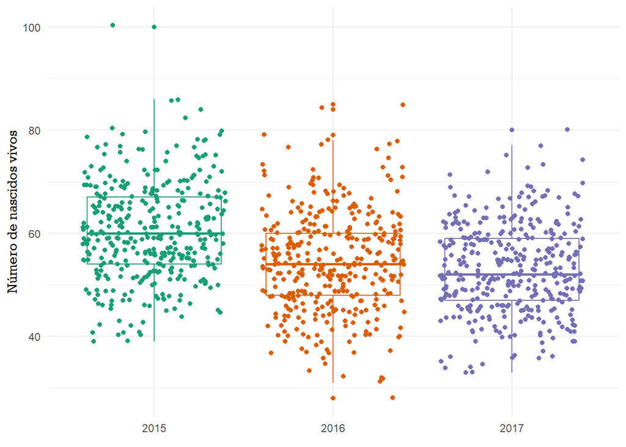

```r
test_results <- data.frame(
  pregnant_per_day = c(intervalo$pregnat_per_day_2015, intervalo$pregnat_per_day_2016, intervalo$pregnat_per_day_2017),
  Ano = c(
    rep("2015", length(intervalo$pregnat_per_day_2015)),
    rep("2016", length(intervalo$pregnat_per_day_2016)),
    rep("2017", length(intervalo$pregnat_per_day_2017))
  )
)

ggplot(test_results, aes(x = Ano, y = pregnant_per_day, color = Ano)) +
  geom_boxplot() +
  geom_jitter() +
  scale_color_brewer(type = "qual", palette = 2) +
  theme_minimal() +
  labs(x= element_blank(),
       y= "Número de nascidos vivos")+
  theme(legend.position = "none",
        axis.title.y = element_text(family = "Rockwell"))
```

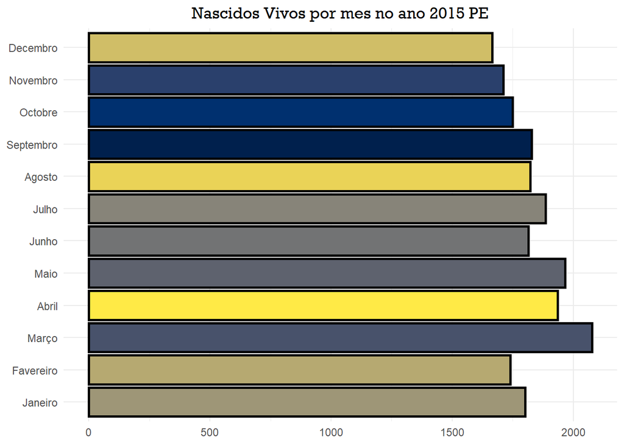

```r
carnaval_prueba <- prueba %>%
  mutate(mes = month(data_nasc)) %>%
  group_by(mes) %>%
  summarise(n = sum(n))

carnaval_prueba2 <- prueba2 %>%
  mutate(mes = month(data_nasc)) %>%
  group_by(mes) %>%
  summarise(n = sum(n))

carnaval_prueba3 <- prueba3 %>%
  mutate(mes = month(data_nasc)) %>%
  group_by(mes) %>%
  summarise(n = sum(n))


intervalo_carnaval <- carnaval_prueba %>%
  left_join(carnaval_prueba2, by = "mes") %>%
  left_join(carnaval_prueba3, by = "mes") %>%
  rename(pregnat_per_month_2015 = n.x,
         pregnat_per_month_2016 = n.y,
         pregnat_per_month_2017 = n)

intervalo_carnaval <- intervalo_carnaval %>%
  mutate(nome_mes =case_when(
    mes %in%  1 ~ "Janeiro",
    mes %in%  2  ~ "Favereiro",
    mes %in%  3  ~ "Março",
    mes %in%  4  ~ "Abril",
    mes %in%  5  ~ "Maio",
    mes %in%  6  ~ "Junho",
    mes %in%  7  ~ "Julho",
    mes %in%  8  ~ "Agosto",
    mes %in%  9  ~ "Septembro",
    mes %in%  10  ~ "Octobre",
    mes %in%  11  ~ "Novembro",
    mes %in%  12  ~ "Decembro"
  ))
intervalo_carnaval <- intervalo_carnaval %>%
  mutate(nome_mes = as.factor(nome_mes),
         mes = as.numeric(mes))


ggplot(intervalo_carnaval, aes(x = fct_reorder(nome_mes,mes), y = pregnat_per_month_2015, fill = nome_mes)) +
  geom_col(show.legend = F, position = "dodge", color="black", size=1)+
  scale_fill_viridis(option = "cividis", direction = -1, discrete = T)+
  theme_minimal()+
  labs(title = "Nascidos Vivos por mes no ano 2015 PE")+
  coord_flip()+
  theme(axis.title.x  = element_blank(),
        axis.title.y = element_blank(),
        plot.title = element_text(family = "Rockwell", hjust = 0.5))
```

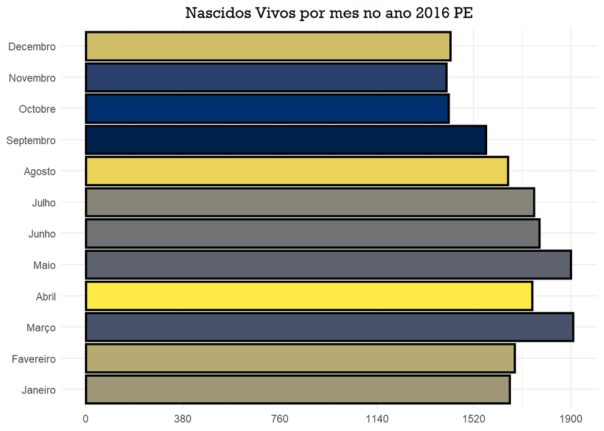

```r
ggplot(intervalo_carnaval, aes(x = fct_reorder(nome_mes,mes), y = pregnat_per_month_2016, fill = nome_mes)) +
  geom_col(show.legend = F, position = "dodge", color="black", size=1)+
  scale_fill_viridis(option = "cividis", direction = -1, discrete = T)+
  theme_minimal()+
  labs(title = "Nascidos Vivos por mes no ano 2016 PE")+
  coord_flip()+
  scale_y_continuous(breaks = seq(0,1900, 380))+
  theme(axis.title.x  = element_blank(),
        axis.title.y = element_blank(),
        plot.title = element_text(family = "Rockwell", hjust = 0.5))
```

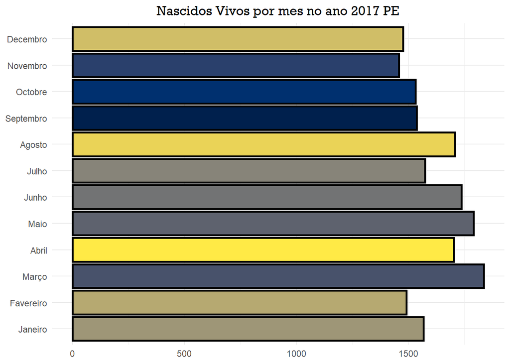

```r
ggplot(intervalo_carnaval, aes(x = fct_reorder(nome_mes,mes), y = pregnat_per_month_2017, fill = nome_mes)) +
  geom_col(show.legend = F, position = "dodge", color="black", size=1)+
  scale_fill_viridis(option = "cividis", direction = -1, discrete = T)+
  theme_minimal()+
  labs(title = "Nascidos Vivos por mes no ano 2017 PE")+
  coord_flip()+
  theme(axis.title.x  = element_blank(),
        axis.title.y = element_blank(),
        plot.title = element_text(family = "Rockwell", hjust = 0.5))
```

# Serie temporal

```r
intervalo_mes <- rbind(carnaval_prueba,carnaval_prueba2, carnaval_prueba3)
intervalo_mes %>%
  mutate(mes = month(mes)) -> intervalo_mes

glimpse(intervalo_mes)
```

```
## Rows: 36
## Columns: 2
## $ mes <dbl> 1, 2, 3, 4, 5, 6, 7, 8, 9, 10, 11, 12, 1, 2, 3, 4, 5, 6, 7, 8, ...
## $ n   <int> 1802, 1740, 2077, 1935, 1966, 1815, 1886, 1822, 1829, 1750, 171...
```

```r
serie <- ts(intervalo_mes$n, start = c(2015,1), frequency = 12)
serie
```

```
##       Jan  Feb  Mar  Apr  May  Jun  Jul  Aug  Sep  Oct  Nov  Dec
## 2015 1802 1740 2077 1935 1966 1815 1886 1822 1829 1750 1711 1666
## 2016 1660 1680 1908 1748 1899 1776 1755 1653 1567 1421 1411 1428
## 2017 1567 1490 1836 1703 1790 1737 1574 1708 1537 1532 1457 1476
```

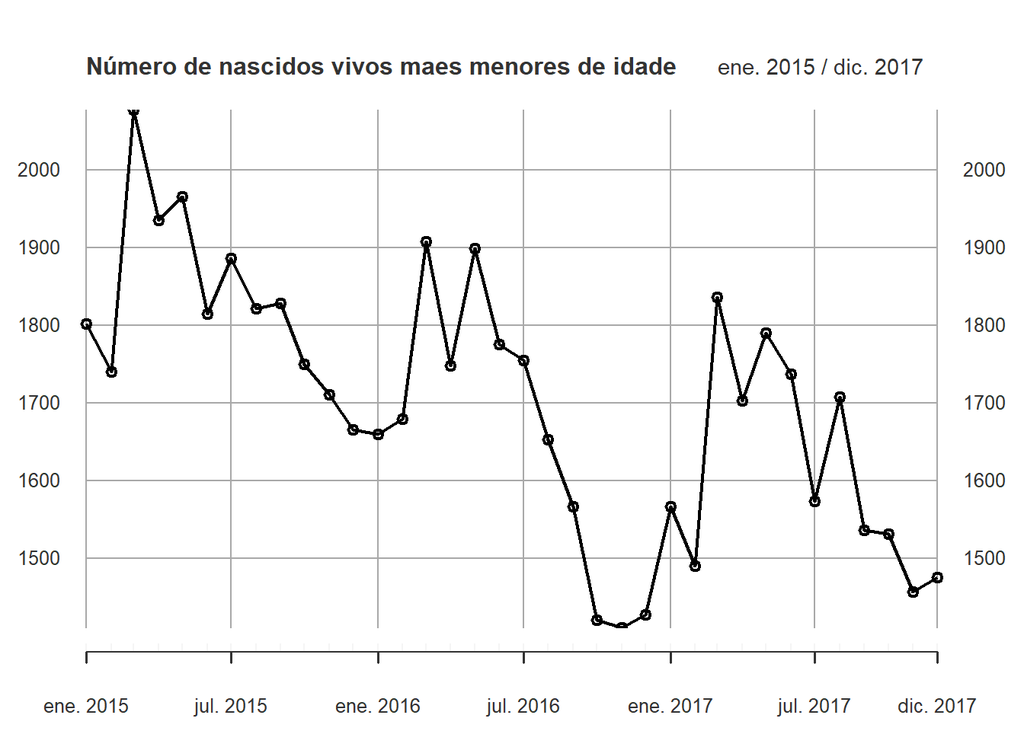

```r
plot(as.xts(serie, major.format = "%Y-%m"), main = "Número de nascidos vivos maes menores de idade", type = "o")
```

```r
adf.test(serie, alternative = "stationary")
```

```
##
##  Augmented Dickey-Fuller Test
##
## data:  serie
## Dickey-Fuller = -4.0743, Lag order = 3, p-value = 0.01805
## alternative hypothesis: stationary
```

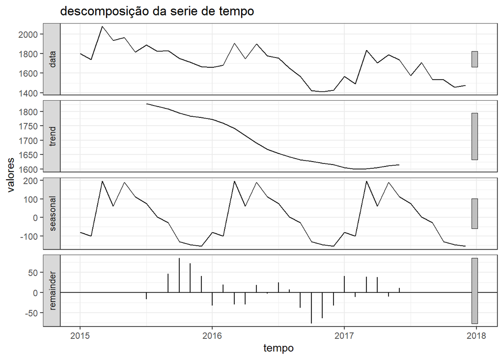

```r
fit <- decompose(serie, type = "additive")

autoplot(fit)+
  labs(title = "descomposição da serie de tempo",
  x="tempo",
  y ="valores",
  colour= "Gears")+
  theme_bw()
```

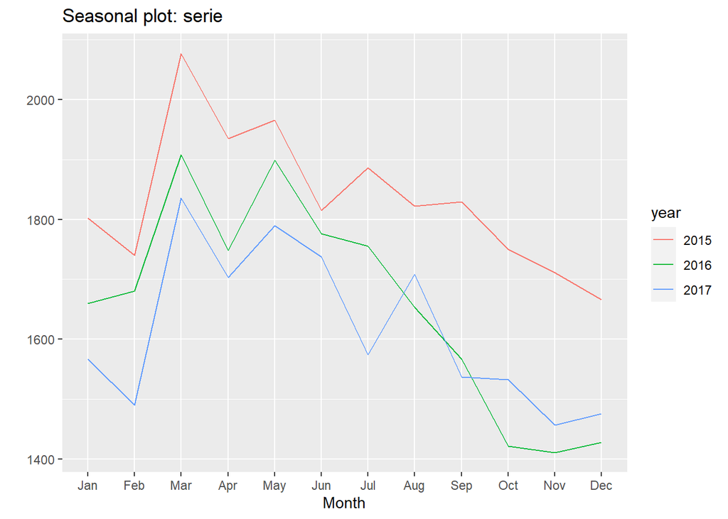

```r
ggseasonplot(serie)
```

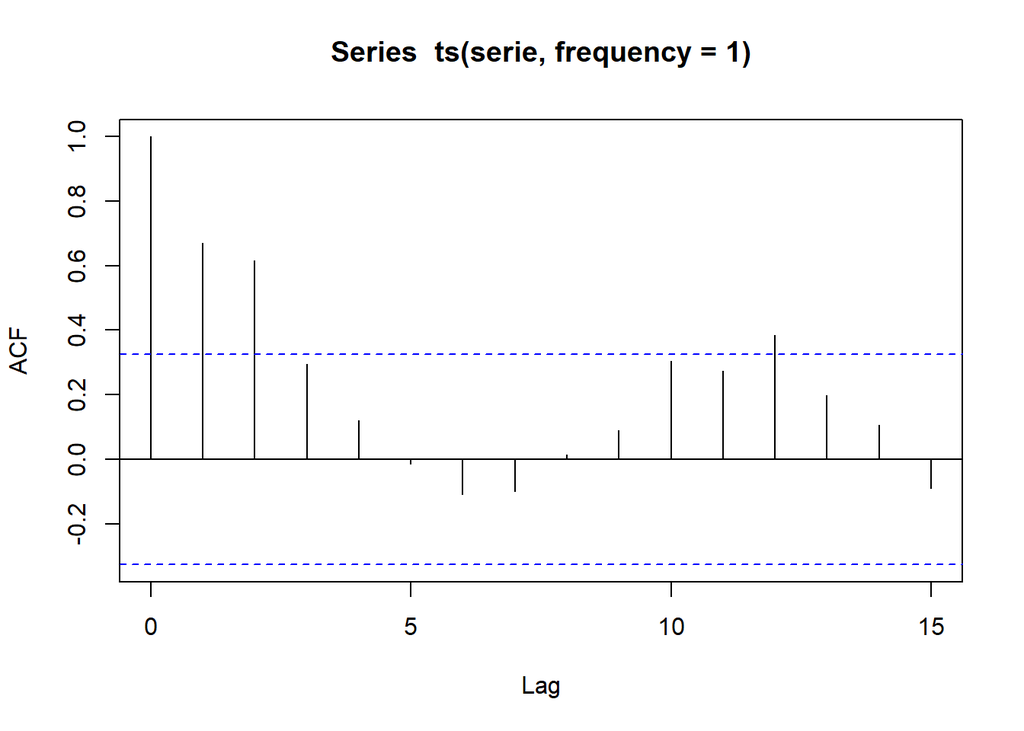

```r
#par(mfrow=c(2,1), mar= c(4,4,4,1)+ 0.01)
acf(ts(serie, frequency = 1))
```

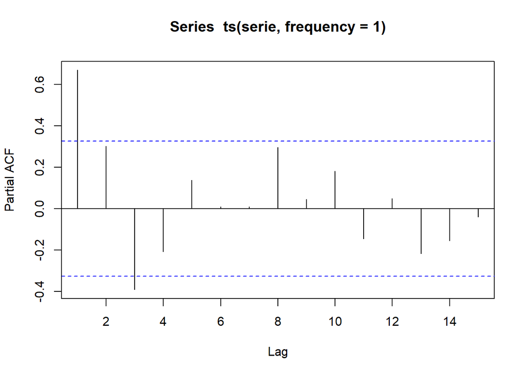

```r
pacf(ts(serie, frequency = 1))
```

## ARIMA

```r
modelo_arima <- auto.arima(serie, d=1, D=1, stepwise = F, approximation = F, trace= F)
print(modelo_arima)
```

```
## Series: serie
## ARIMA(1,1,0)(1,1,0)[12]
##
## Coefficients:
##           ar1     sar1
##       -0.6025  -0.6466
## s.e.   0.1752   0.2052
##
## sigma^2 estimated as 5259:  log likelihood=-133.59
## AIC=273.17   AICc=274.43   BIC=276.58
```

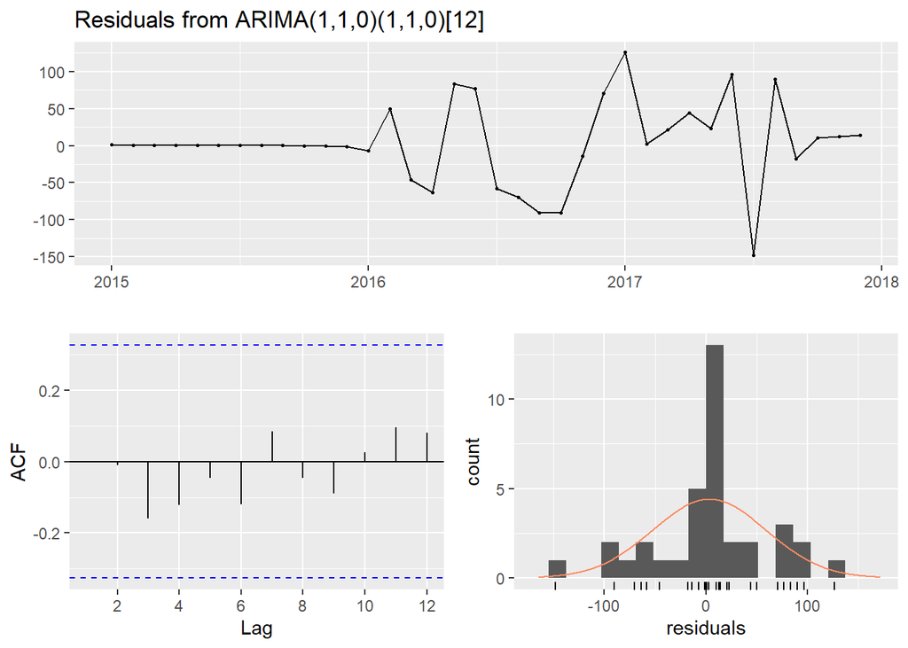

```
##
##  Ljung-Box test
##
## data:  Residuals from ARIMA(1,1,0)(1,1,0)[12]
## Q* = 2.786, df = 5, p-value = 0.7329
##
## Model df: 2.   Total lags used: 7
```

```r
checkresiduals(modelo_arima)
```

## Predisão

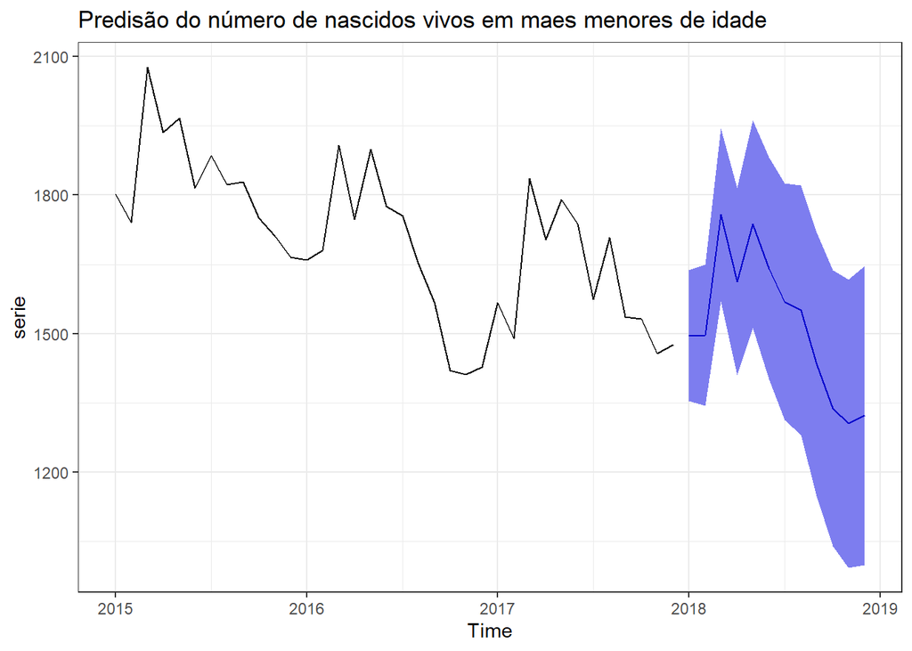

```r
frcst <- forecast(modelo_arima, h = 12, level = c(95))
autoplot(frcst)+
  ggtitle("Predisão do número de nascidos vivos em maes menores de idade")+
  theme_bw()
```

# Analise de nascidos vivos entre menores de idade e jovenes(faixa entre 19 e 25 anos)

```r
ano2015 %>%
  filter(idademae <= 25) %>%
  select(data_nasc, idademae) %>%
  mutate(idademae = case_when(
    idademae %in%  9 ~ "Menor_idade",
    idademae %in%  10 ~ "Menor_idade",
    idademae %in%  11 ~ "Menor_idade",
    idademae %in%  12 ~ "Menor_idade",
    idademae %in%  13 ~ "Menor_idade",
    idademae %in%  14 ~ "Menor_idade",
    idademae %in%  15 ~ "Menor_idade",
    idademae %in%  16 ~ "Menor_idade",
    idademae %in%  17 ~ "Menor_idade",
    idademae %in%  18 ~ "Menor_idade",
    idademae %in%  19 ~ "Joven",
    idademae %in%  20 ~ "Joven",
    idademae %in%  21 ~ "Joven",
    idademae %in%  22 ~ "Joven",
    idademae %in%  23 ~ "Joven",
    idademae %in%  24 ~ "Joven",
    idademae %in%  25 ~ "Joven",
    ),
    idademae = as.factor(idademae)) %>%
  group_by(data_nasc,idademae) %>%
  count(data_nasc, sort="F") %>%
  ungroup() %>%
  mutate(key = c(1:730)) -> menores_idade_2015

ano2016 %>%
  filter(idademae <= 25) %>%
  select(data_nasc, idademae) %>%
  mutate(idademae = case_when(
    idademae %in%  9 ~ "Menor_idade",
    idademae %in%  10 ~ "Menor_idade",
    idademae %in%  11 ~ "Menor_idade",
    idademae %in%  12 ~ "Menor_idade",
    idademae %in%  13 ~ "Menor_idade",
    idademae %in%  14 ~ "Menor_idade",
    idademae %in%  15 ~ "Menor_idade",
    idademae %in%  16 ~ "Menor_idade",
    idademae %in%  17 ~ "Menor_idade",
    idademae %in%  18 ~ "Menor_idade",
    idademae %in%  19 ~ "Joven",
    idademae %in%  20 ~ "Joven",
    idademae %in%  21 ~ "Joven",
    idademae %in%  22 ~ "Joven",
    idademae %in%  23 ~ "Joven",
    idademae %in%  24 ~ "Joven",
    idademae %in%  25 ~ "Joven",
  ),
  idademae = as.factor(idademae)) %>%
  group_by(data_nasc,idademae) %>%
  count(data_nasc, sort="F") %>%
  ungroup() %>%
  mutate(key = c(1:732))-> menores_idade_2016


ano2017 %>%
  filter(idademae <= 25) %>%
  select(data_nasc, idademae) %>%
  mutate(idademae = case_when(
    idademae %in%  9 ~ "Menor_idade",
    idademae %in%  10 ~ "Menor_idade",
    idademae %in%  11 ~ "Menor_idade",
    idademae %in%  12 ~ "Menor_idade",
    idademae %in%  13 ~ "Menor_idade",
    idademae %in%  14 ~ "Menor_idade",
    idademae %in%  15 ~ "Menor_idade",
    idademae %in%  16 ~ "Menor_idade",
    idademae %in%  17 ~ "Menor_idade",
    idademae %in%  18 ~ "Menor_idade",
    idademae %in%  19 ~ "Joven",
    idademae %in%  20 ~ "Joven",
    idademae %in%  21 ~ "Joven",
    idademae %in%  22 ~ "Joven",
    idademae %in%  23 ~ "Joven",
    idademae %in%  24 ~ "Joven",
    idademae %in%  25 ~ "Joven",
  ),
  idademae = as.factor(idademae)) %>%
  group_by(data_nasc,idademae) %>%
  count(data_nasc, sort="F") %>%
  ungroup() %>%
  mutate(key = c(1:730))-> menores_idade_2017

comparacion_jovenes_menores <- menores_idade_2015 %>%
  left_join(menores_idade_2016, by = "key") %>%
  left_join(menores_idade_2017, by = "key") %>%
  rename(pregnat_per_day_2015 = n.x,
         pregnat_per_day_2016 = n.y,
         pregnat_per_day_2017 = n)

jovenes <- comparacion_jovenes_menores %>%
  select(-c(idademae.x ,idademae.y)) %>%
  filter(idademae == "Joven")

comparacion_menor_joven<- rbind(menores_idade_2015, menores_idade_2016, menores_idade_2017)
```

### teste de aderencia KS

```r
kolmogorov <- sapply(jovenes[,c(2,5,8)], function(y) {
  ks <- ks.test(y, "pnorm", mean(y), sd(y))
  c(statistic=ks$statistic, p.value=ks$p.value)
  setNames(c(ks$statistic, ks$p.value), c("Statistic", "P.value"))
})

kolmogorov
```

```
##           pregnat_per_day_2015 pregnat_per_day_2016 pregnat_per_day_2017
## Statistic           0.05551122           0.03539637           0.04305266
## P.value             0.21065832           0.75032619           0.50797488
```

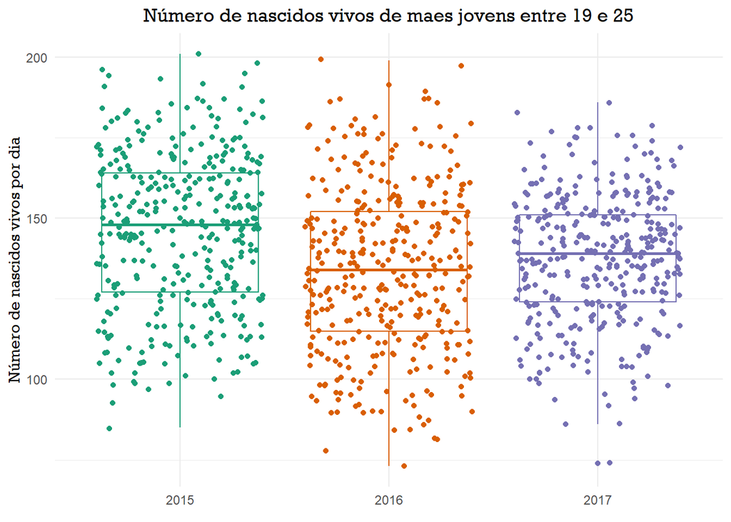

```r
test_results <- data.frame(
  pregnant_per_day = c(jovenes$pregnat_per_day_2015, jovenes$pregnat_per_day_2016, jovenes$pregnat_per_day_2017),
  Ano = c(
    rep("2015", length(jovenes$pregnat_per_day_2015)),
    rep("2016", length(jovenes$pregnat_per_day_2016)),
    rep("2017", length(jovenes$pregnat_per_day_2017))
  )
)

ggplot(test_results, aes(x = Ano, y = pregnant_per_day, color = Ano)) +
  geom_boxplot() +
  labs(title = "Número de nascidos vivos de maes jovens entre 19 e 25")+
  geom_jitter() +
  labs(x= element_blank(),
       y = "Número de nascidos vivos por dia")+
  scale_color_brewer(type = "qual", palette = 2) +
  theme_minimal() +
  theme(legend.position = "none",
        plot.title = element_text(family = "Rockwell", hjust = 0.5),
        axis.title.y = element_text(family = "Rockwell"))
```

### ANOVA

```r
anova<-aov(comparacion_menor_joven$n ~ comparacion_menor_joven$idademae)
summary(anova)
```

```
##                                    Df  Sum Sq Mean Sq F value Pr(>F)
## comparacion_menor_joven$idademae    1 3792705 3792705   11493 <2e-16 ***
## Residuals                        2190  722686     330
## ---
## Signif. codes:  0 '***' 0.001 '**' 0.01 '*' 0.05 '.' 0.1 ' ' 1
```

```r
TukeyHSD(anova)
```

```
##   Tukey multiple comparisons of means
##     95% family-wise confidence level
##
## Fit: aov(formula = comparacion_menor_joven$n ~ comparacion_menor_joven$idademae)
##
## $`comparacion_menor_joven$idademae`
##                        diff       lwr       upr p adj
## Menor_idade-Joven -83.19252 -84.71429 -81.67074     0
```

Existe evidencia suficiente para afirmar que as jovens entre 19 e 25 anos tem mais filhos do que as menores de idade no estado de Pernambuco.

### Analise de gravidas menores de idade pela raça

## Pre-processamento

```r
ano2015 %>%
  filter(idademae <= 18) %>%
  select(data_nasc, def_raca_cor) %>%
  group_by(data_nasc,def_raca_cor) %>%
  mutate( def_raca_cor= as.factor(def_raca_cor)) %>%
  count(data_nasc, sort="F") %>%
  ungroup() %>%
  mutate(key = c(1:1358)) -> menores_raca_2015


ano2016 %>%
  filter(idademae <= 18) %>%
  select(data_nasc, def_raca_cor) %>%
  group_by(data_nasc,def_raca_cor) %>%
  mutate( def_raca_cor= as.factor(def_raca_cor)) %>%
  count(data_nasc, sort="F") %>%
  ungroup() %>%
  mutate(key = c(1:1380)) -> menores_raca_2016

ano2017 %>%
    filter(idademae <= 18) %>%
    select(data_nasc, def_raca_cor) %>%
    group_by(data_nasc,def_raca_cor) %>%
    mutate( def_raca_cor= as.factor(def_raca_cor)) %>%
    count(data_nasc, sort="F") %>%
  ungroup() %>%
    mutate(key = c(1:1406)) -> menores_raca_2017


menores_raca <- menores_raca_2017 %>%
  left_join(menores_raca_2016, by = "key") %>%
  left_join(menores_raca_2015, by = "key") %>%
  rename(pregnat_per_day_2017 = n.x,
         pregnat_per_day_2016 = n.y,
         pregnat_per_day_2015 = n) %>%
  select(-c(key))

raca_geral <- rbind(menores_raca_2015, menores_raca_2016, menores_raca_2017)
raca_geral <- filter(raca_geral, def_raca_cor %in% c("Amarela", "Branca", "Indígena", "Parda", "Preta"))

raca_geral <- raca_geral %>%
  mutate(def_raca_cor = as.character(def_raca_cor),
          def_raca_cor = as.factor(def_raca_cor))
```

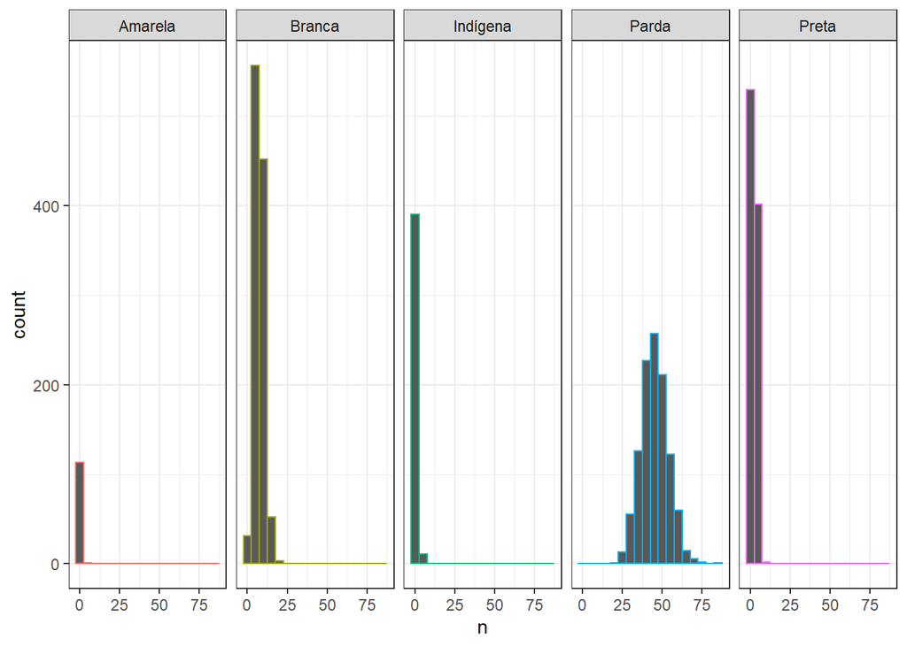

```r
ggplot(data = raca_geral, mapping = aes(x = n, colour = def_raca_cor)) +
  geom_histogram(binwidth = 5) +
  theme_bw() +
  facet_grid(. ~ def_raca_cor) +
  theme(legend.position = "none")
```

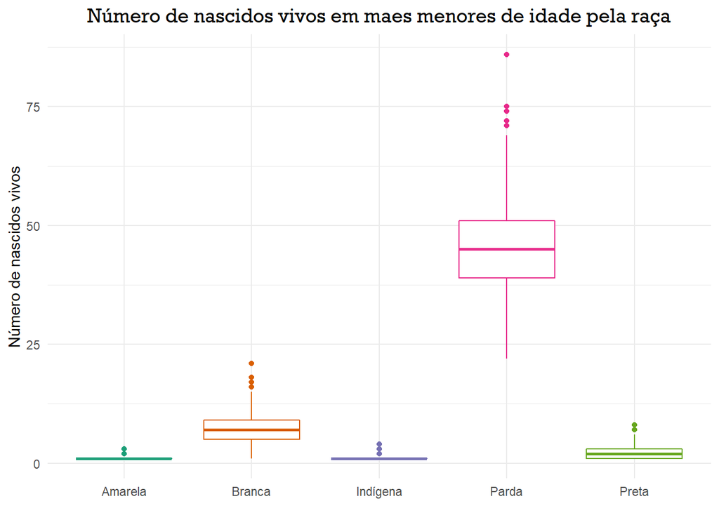

```r
ggplot(raca_geral, aes(x =def_raca_cor, y =n, color = def_raca_cor)) +
  geom_boxplot() +
  scale_color_brewer(type = "qual", palette = 2) +
  theme_minimal() +
  labs(title = "Número de nascidos vivos em maes menores de idade pela raça",
       y= "Número de nascidos vivos",
       x= element_blank())+
  theme(legend.position = "none",
         plot.title = element_text(family = "Rockwell", hjust = 0.5, size= 14))
```

## Teste de aderencia KS

```r
branco<- raca_geral %>%
  filter(def_raca_cor =="Branca")
parda<- raca_geral %>%
  filter(def_raca_cor =="Parda")
preta<- raca_geral %>%
  filter(def_raca_cor =="Preta")
indigena<- raca_geral %>%
  filter(def_raca_cor =="Indígena")
amarela <- raca_geral %>%
  filter(def_raca_cor =="Amarela")



ks.test(branco$n,"pnorm",mean(branco$n),
        sd(branco$n))
```

```
##
##  One-sample Kolmogorov-Smirnov test
##
## data:  branco$n
## D = 0.10126, p-value = 3.611e-10
## alternative hypothesis: two-sided
```

```r
ks.test(parda$n,"pnorm",mean(parda$n),
        sd(parda$n))
```

```
##
##  One-sample Kolmogorov-Smirnov test
##
## data:  parda$n
## D = 0.039472, p-value = 0.06574
## alternative hypothesis: two-sided
```

```r
ks.test(preta$n,"pnorm",mean(preta$n),
        sd(preta$n))
```

```
##
##  One-sample Kolmogorov-Smirnov test
##
## data:  preta$n
## D = 0.18748, p-value < 2.2e-16
## alternative hypothesis: two-sided
```

```r
ks.test(indigena$n,"pnorm",mean(indigena$n),
        sd(indigena$n))
```

```
##
##  One-sample Kolmogorov-Smirnov test
##
## data:  indigena$n
## D = 0.48562, p-value < 2.2e-16
## alternative hypothesis: two-sided
```

```r
ks.test(amarela$n,"pnorm",mean(amarela$n),
        sd(amarela$n))
```

```
##
##  One-sample Kolmogorov-Smirnov test
##
## data:  amarela$n
## D = 0.53559, p-value < 2.2e-16
## alternative hypothesis: two-sided
```

### Teste de Kruskal-Wallis e Post-Hoc Wilcoxon Rank

```r
fligner.test(n ~ def_raca_cor, data = raca_geral)
```

```
##
##  Fligner-Killeen test of homogeneity of variances
##
## data:  n by def_raca_cor
## Fligner-Killeen:med chi-squared = 1775.5, df = 4, p-value < 2.2e-16
```

```r
kruskal.test(n ~ def_raca_cor, data = raca_geral)
```

```
##
##  Kruskal-Wallis rank sum test
##
## data:  n by def_raca_cor
## Kruskal-Wallis chi-squared = 3190.3, df = 4, p-value < 2.2e-16
```

```r
pairwise.wilcox.test(x = raca_geral$n, g = raca_geral$def_raca_cor, p.adjust.method = "holm" )
```

```
##
##  Pairwise comparisons using Wilcoxon rank sum test
##
## data:  raca_geral$n and raca_geral$def_raca_cor
##
##          Amarela Branca  Indígena Parda
## Branca   < 2e-16 -       -        -
## Indígena 0.00053 < 2e-16 -        -
## Parda    < 2e-16 < 2e-16 < 2e-16  -
## Preta    < 2e-16 < 2e-16 < 2e-16  < 2e-16
##
## P value adjustment method: holm
```

```r
oneway.test(n ~ def_raca_cor, data = raca_geral, var.equal=FALSE)
```

```
##
##  One-way analysis of means (not assuming equal variances)
##
## data:  n and def_raca_cor
## F = 8593.9, num df = 4, denom df = 1195, p-value < 2.2e-16
```

```r
with(raca_geral, pairwise.t.test(n, def_raca_cor, pool.sd=FALSE))
```

```
##
##  Pairwise comparisons using t tests with non-pooled SD
##
## data:  n and def_raca_cor
##
##          Amarela Branca  Indígena Parda
## Branca   < 2e-16 -       -        -
## Indígena 1.5e-05 < 2e-16 -        -
## Parda    < 2e-16 < 2e-16 < 2e-16  -
## Preta    < 2e-16 < 2e-16 < 2e-16  < 2e-16
##
## P value adjustment method: holm
```

```r
ano2015 %>%
  filter(idademae <= 18) %>%
  select(data_nasc, consprenat, def_escol_mae,idademae, qtdfilvivo) %>%
   filter(consprenat <=25) %>%
  drop_na(consprenat)-> escolaridade_mae2015

ano2016 %>%
  filter(idademae <= 18) %>%
  select(data_nasc, consprenat, def_escol_mae, idademae, qtdfilvivo) %>%
  filter(consprenat <=25) %>%
  drop_na(consprenat)-> escolaridade_mae2016

ano2017 %>%
  filter(idademae <= 18) %>%
  select(data_nasc, consprenat, def_escol_mae, idademae, qtdfilvivo) %>%
  filter(consprenat <=25) %>%
  drop_na(consprenat)-> escolaridade_mae2017

escolaridade_mae <- rbind(escolaridade_mae2015,escolaridade_mae2016,escolaridade_mae2017)
escolaridade_mae <- escolaridade_mae %>%
  filter(def_escol_mae %in% c("Nenhuma", "1 a 3 anos", "4 a 7 anos", "8 a 11 anos", "12 e mais")) %>%
  mutate(def_escol_mae = as.character(def_escol_mae)) %>%
  mutate(def_escol_mae = as.factor(def_escol_mae))

escolaridade_mae$def_escol_mae <- factor(escolaridade_mae$def_escol_mae, levels = c("Nenhuma", "1 a 3 anos", "4 a 7 anos", "8 a 11 anos", "12 e mais"))
```

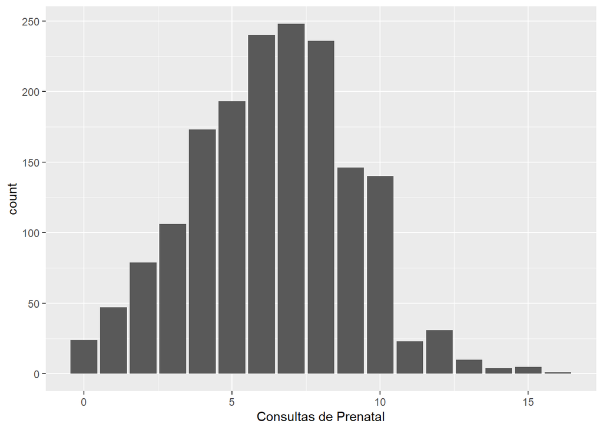

```r
escol_1a3 <- escolaridade_mae %>%
  filter(def_escol_mae == "1 a 3 anos")
escol_1a3  %>%
  mutate(def_escol_mae  =  as.character(def_escol_mae)) %>%
  mutate(def_escol_mae = as.factor(def_escol_mae)) -> escol_1a3

ggplot(escol_1a3, mapping = aes(x= consprenat))+
  geom_bar()+
  labs(x= "Consultas de Prenatal")
```

```r
summary(escol_1a3$def_escol_mae)
```

```
## 1 a 3 anos
##       1706
```

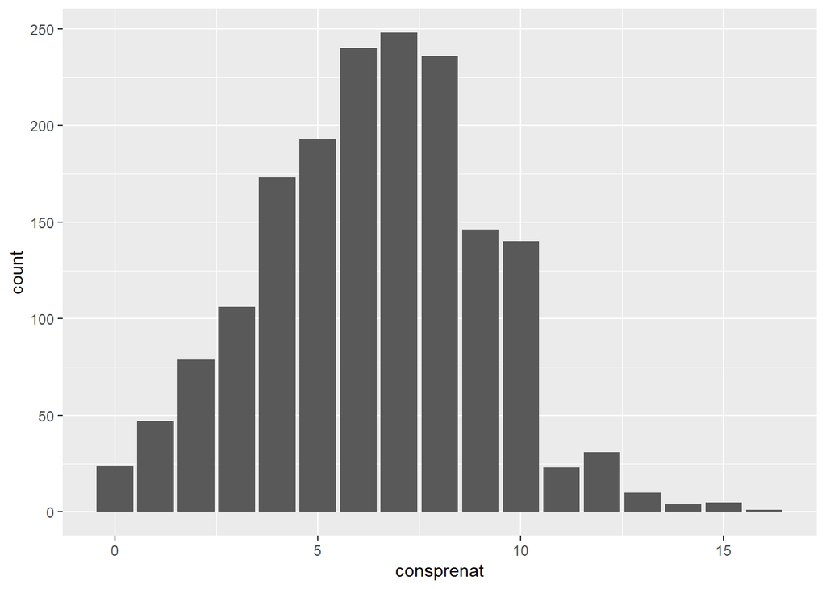

```r
ggplot(escol_1a3, mapping = aes(x= consprenat))+
  geom_bar()
```

```r
ks.test(escol_1a3$consprenat, "pnorm",mean(escol_1a3$consprenat), sd(escol_1a3$consprenat))
```

```
##
##  One-sample Kolmogorov-Smirnov test
##
## data:  escol_1a3$consprenat
## D = 0.086956, p-value = 1.249e-11
## alternative hypothesis: two-sided
```

Embora os outliers foram tirados não foi determinante no teste de aderencia.

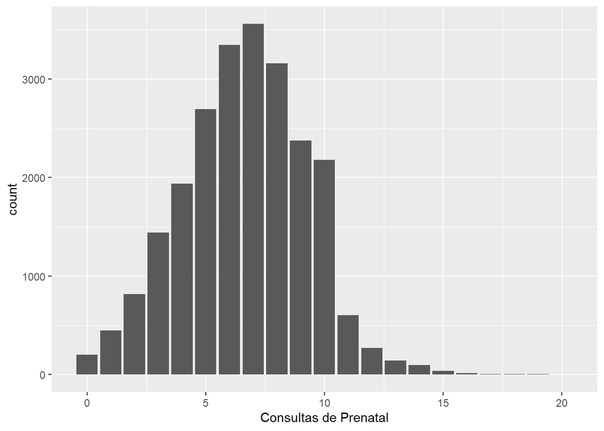

```r
escolaridade_mae %>%
  filter(def_escol_mae == "4 a 7 anos",
         ) -> escol_4a7

escol_4a7  %>%
  mutate(def_escol_mae  =  as.character(def_escol_mae)) %>%
  mutate(def_escol_mae = as.factor(def_escol_mae)) -> escol_4a7

ggplot(escol_4a7, mapping = aes(x= consprenat))+
  geom_bar()+
  labs(x= "Consultas de Prenatal")
```

```r
escol_4a7 %>%
  filter(consprenat >= 25) %>%
  head(10)
```

```
## [1] data_nasc     consprenat    def_escol_mae idademae      qtdfilvivo
## <0 rows> (or 0-length row.names)
```

```r
ks.test(escol_4a7$consprenat, "pnorm",mean(escol_4a7$consprenat), sd(escol_4a7$consprenat))
```

```
##
##  One-sample Kolmogorov-Smirnov test
##
## data:  escol_4a7$consprenat
## D = 0.085985, p-value < 2.2e-16
## alternative hypothesis: two-sided
```

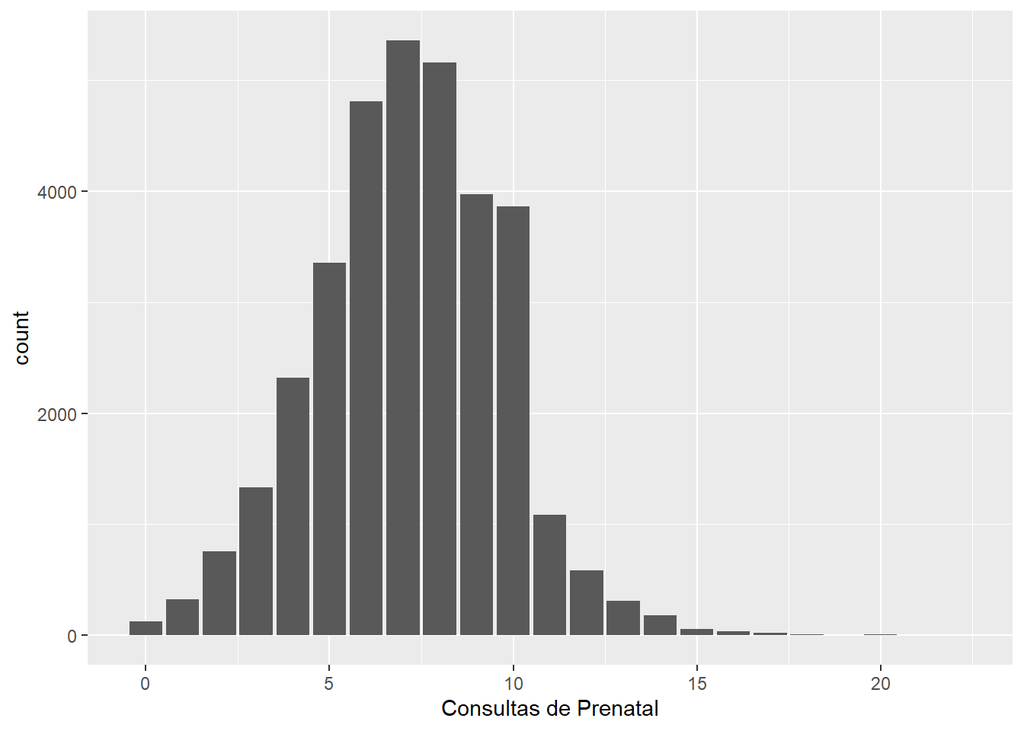

```r
escolaridade_mae %>%
  filter(def_escol_mae == "8 a 11 anos") -> escol_8a11

escol_8a11  %>%
  mutate(def_escol_mae  =  as.character(def_escol_mae)) %>%
  mutate(def_escol_mae = as.factor(def_escol_mae)) -> escol_8a11

ggplot(escol_8a11, mapping = aes(x= consprenat))+
  geom_bar()+
  labs(x= "Consultas de Prenatal")
```

```r
escol_8a11 %>%
  filter(consprenat > 20) %>%
  head(10)
```

```
##    data_nasc consprenat def_escol_mae idademae qtdfilvivo
## 1 2016-01-22         22   8 a 11 anos       18          0
```

```r
ks.test(escol_4a7$consprenat, "pnorm",mean(escol_4a7$consprenat), sd(escol_4a7$consprenat))
```

```
##
##  One-sample Kolmogorov-Smirnov test
##
## data:  escol_4a7$consprenat
## D = 0.085985, p-value < 2.2e-16
## alternative hypothesis: two-sided
```

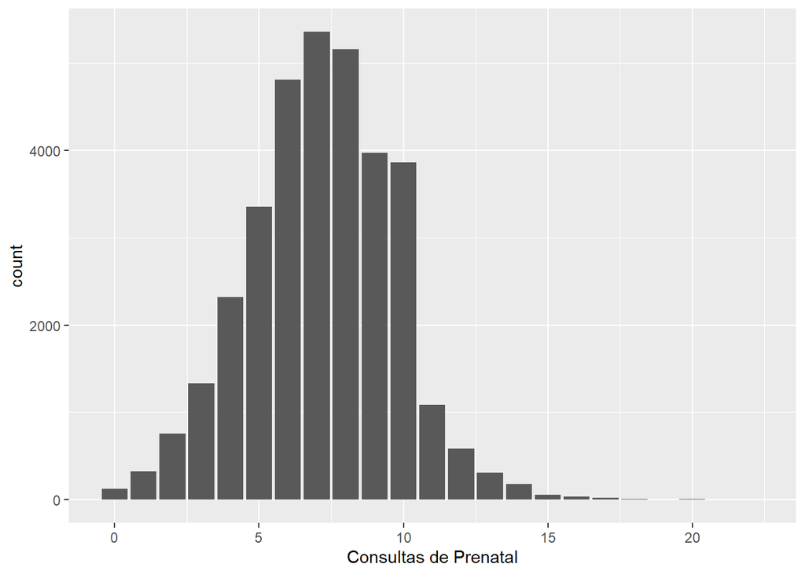

```r
escolaridade_mae %>%
  filter(def_escol_mae == "12 e mais") -> escol_12amais

escol_12amais  %>%
  mutate(def_escol_mae  =  as.character(def_escol_mae)) %>%
  mutate(def_escol_mae = as.factor(def_escol_mae)) -> escol_12amais

ggplot(escol_8a11, mapping = aes(x= consprenat))+
  geom_bar()+
  labs(x= "Consultas de Prenatal")
```

```r
escol_12amais %>%
  filter(consprenat >=25) %>%
  head(10)
```

```
## [1] data_nasc     consprenat    def_escol_mae idademae      qtdfilvivo
## <0 rows> (or 0-length row.names)
```

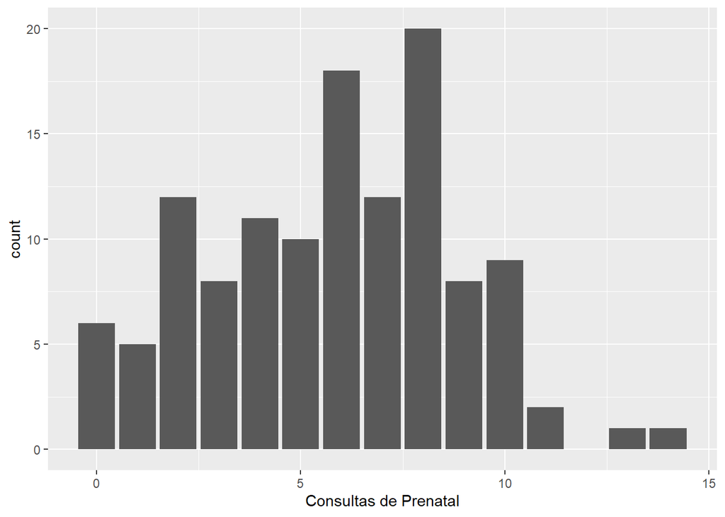

```r
escolaridade_mae %>%
  filter(def_escol_mae == "Nenhuma") -> escol_nenhuma

escol_nenhuma  %>%
  mutate(def_escol_mae  =  as.character(def_escol_mae)) %>%
  mutate(def_escol_mae = as.factor(def_escol_mae)) -> escol_nenhuma

ggplot(escol_nenhuma, mapping = aes(x= consprenat))+
  geom_bar()+
  labs(x= "Consultas de Prenatal")
```

```r
escol_nenhuma %>%
  filter(consprenat >=25)
```

```
## [1] data_nasc     consprenat    def_escol_mae idademae      qtdfilvivo
## <0 rows> (or 0-length row.names)
```

## Teste Kruskall Wallis

```r
kruskal.test(escolaridade_mae$consprenat ~ escolaridade_mae$def_escol_mae, data = escolaridade_mae)
```

```
##
##  Kruskal-Wallis rank sum test
##
## data:  escolaridade_mae$consprenat by escolaridade_mae$def_escol_mae
## Kruskal-Wallis chi-squared = 624.24, df = 4, p-value < 2.2e-16
```

```r
pairwise.wilcox.test(x = escolaridade_mae$consprenat, g = escolaridade_mae$def_escol_mae, p.adjust.method = "holm" )
```

```
##
##  Pairwise comparisons using Wilcoxon rank sum test
##
## data:  escolaridade_mae$consprenat and escolaridade_mae$def_escol_mae
##
##             Nenhuma 1 a 3 anos 4 a 7 anos 8 a 11 anos
## 1 a 3 anos  0.10933 -          -          -
## 4 a 7 anos  0.00641 0.00013    -          -
## 8 a 11 anos 2.9e-06 < 2e-16    < 2e-16    -
## 12 e mais   6.0e-06 3.1e-10    1.3e-06    0.34947
##
## P value adjustment method: holm
```

## Grafico de caixa

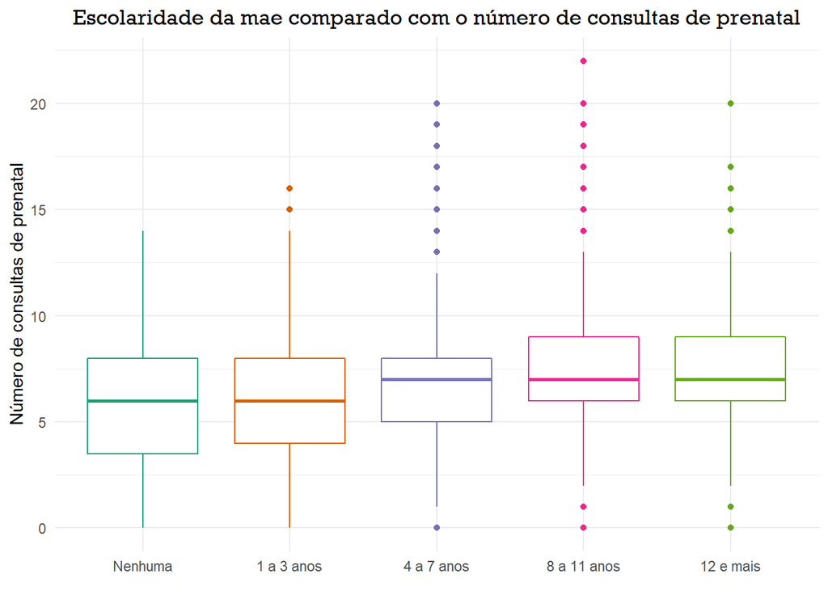

```r
ggplot(escolaridade_mae, aes(x = def_escol_mae, y = consprenat, color = def_escol_mae)) +
  geom_boxplot() +
  scale_color_brewer(type = "qual", palette = 2) +
  theme_minimal() +
  labs(title = "Escolaridade da mae comparado com o número de consultas de prenatal",
       y= "Número de consultas de prenatal",
       x= element_blank())+
  theme(legend.position = "none",
         plot.title = element_text(family = "Rockwell", hjust = 0.5))
```

# Relação entre o número de consultas de uma mae menor de idade y o peso da criança

```r
ano2015 %>%
  filter(idademae <= 18) %>%
  select(data_nasc, consprenat, peso) %>%
   filter(consprenat <=20) %>%
  drop_na(consprenat) -> peso_crianca2015

ano2016 %>%
  filter(idademae <= 18) %>%
  select(data_nasc, consprenat,peso) %>%
  filter(consprenat <=20) %>%
  drop_na(consprenat) -> peso_crianca2016

ano2017 %>%
  filter(idademae <= 18) %>%
  select(data_nasc, consprenat, peso) %>%
  filter(consprenat <=20) %>%
  drop_na(consprenat) -> peso_crianca2017


peso_crianca <- rbind(peso_crianca2015, peso_crianca2016, peso_crianca2017)
peso_crianca <- peso_crianca %>%
  drop_na(peso) %>%
  mutate(peso = case_when(
    peso <= 2500 ~ "Peso ruim",
    peso > 2500 ~ "Peso ideal",
  )) %>%
  mutate(peso =  as.factor(peso))


summary(peso_crianca$peso)
```

```
## Peso ideal  Peso ruim
##      54123       5757
```

## Teste de aderencia

```r
peso_ideal <- peso_crianca %>%
  filter(peso == "Peso ideal")

peso_ruim <- peso_crianca %>%
  filter(peso == "Peso ruim")


ks.test(peso_ideal$consprenat, "pnorm", mean(peso_ideal$consprenat), sd(peso_ideal$consprenat))
```

```
##
##  One-sample Kolmogorov-Smirnov test
##
## data:  peso_ideal$consprenat
## D = 0.08827, p-value < 2.2e-16
## alternative hypothesis: two-sided
```

```r
ks.test(peso_ruim$consprenat, "pnorm", mean(peso_ruim$consprenat), sd(peso_ruim$consprenat))
```

```
##
##  One-sample Kolmogorov-Smirnov test
##
## data:  peso_ruim$consprenat
## D = 0.083246, p-value < 2.2e-16
## alternative hypothesis: two-sided
```